# Analisis Berbagi Sepeda Cyclistic

Samsur Hidayat

### 1. Pendahuluan & Objektif Bisnis (Ask)

Proyek ini adalah studi kasus untuk program *Google Data Analytics Capstone*. Tujuan analisis ini adalah untuk memahami bagaimana pelanggan *Casual* dan *Member* tahunan menggunakan sepeda secara berbeda.

1. Tujuan Bisnis  
   Meningkatkan profitabilitas jangka panjang perusahaan dengan memaksimalkan jumlah member melalui konversi pengendara casual.
2. Pertanyaan Kunci  
   Bagaimana perilaku pengguna *casual* berbeda dari *member*?
3. Target Akhir  
   Merancang strategi pemasaran untuk mengubah pengendara casual menjadi member tahunan.

### 2. Persiapan Data (Prepare)

Analisis ini menggunakan dataset historis perjalanan Cyclistic (perusahaan bike-sharing di Chicago) selama 12 bulan terakhir. Saya memverifikasi integritas data untuk memastikan data ini kredibel, orisinal, komprehensif, dan terkini untuk memastikan kualitas analisis.

1. Sumber dan Lisensi Data
   - **Penyedia Data**: Data ini disediakan oleh **Motivate International Inc.**.
   - **Cakupan Waktu**: Data yang dianalisis mencakup periode **12 bulan terakhir** (2025) perjalanan bersepeda.
   - **Status Hukum**: Ini adalah data publik yang dapat digunakan secara bebas untuk mengeksplorasi perbedaan perilaku antara berbagai jenis pelanggan.
2. Komposisi dan Organisasi Data
   - **Struktur**: Data diatur dalam format file **.CSV** dan dibagi perbulan yang berisi informasi geografis dan waktu untuk setiap perjalanan.
   - **Variabel Kunci**: Kolom utama yang digunakan mencakup waktu mulai/berakhir perjalanan (`started_at` dan `ended_at`), serta kategori pengguna (`member_casual`) yang membedakan antara anggota tahunan dan pengendara kasual.
3. Privasi dan Etika
   - **Privasi Data**: Sesuai dengan aturan privasi data, informasi pengenal pribadi (PII) pengendara **tidak disertakan**.
   - **Keterbatasan**: Karena anonimitas ini, analisis tidak dapat menentukan apakah pengendara kasual tinggal di area layanan Cyclistic atau frekuensi pembelian tiket tunggal secara individu.

### 3. Pembersihan Data (Process)

1. Mengingat data Cyclistic terdiri dari 12 file terpisah dengan volume total jutaan baris , langkah pertama yang saya lakukan dalam tahap **Process** adalah memastikan integritas skema. Saya perlu memverifikasi bahwa seluruh file memiliki struktur kolom dan tipe data yang seragam sebelum melakukan penggabungan dengan kueri berikut ini.

   ```sql
   -- Mengintip struktur kolom dari seluruh file CSV secara otomatis menggunakan DuckDB
   DESCRIBE SELECT * FROM read_csv_auto('D:/lokasi data/file_csv/*.csv');
   ```

   Berdasarkan hasil audit menggunakan fungsi `DESCRIBE` dan `read_csv_auto`, terkonfirmasi bahwa seluruh 12 file memiliki 13 kolom yang identik dengan tipe data `TIMESTAMP` pada kolom waktu. Hal ini menjamin bahwa proses penggabungan data (Data Union) nantinya tidak akan mengalami kegagalan skema.
2. Query yang digunakan untuk penggabungan data dan juga validasi penggabungan.

```sql
    -- Membuat tabel master permanen dari gabungan 12 file
    CREATE TABLE all_trips_raw AS
    SELECT * FROM read_csv_auto('D:/lokasi data/file_csv/*.csv')

    -- 1. Mengecek total baris
    SELECT COUNT(*) AS total_rows FROM all_trips_raw;

    -- 2. Memastikan distribusi data per bulan
    SELECT
        extract(month from started_at) as bulan,
        count(*) as jumlah_per_bulan
    FROM all_trips_raw
    GROUP BY bulan
    ORDER BY bulan;
```

Setelah memvalidasi skema data, saya menggabungkan 12 dataset bulanan menjadi satu tabel master bernama `all_trips_raw`. Dengan menggunakan fungsi `read_csv_auto` pada DuckDB, proses penggabungan dilakukan secara otomatis dengan tetap mempertahankan integritas tipe data pada setiap kolom dan menghasilkan *5.552.994* total baris.

3. Proses pembersihan data dengan SQL (DuckDB).
   - Pemeriksaan Duplikasi

```sql
        -- 1. Membuat tabel baru yang bersih dari baris duplikat identik (exact match)
        CREATE TABLE all_trips_cleaned AS
        SELECT DISTINCT * FROM all_trips_raw;

        -- 2. Memvalidasi integritas Primary Key: Memastikan tidak ada ride_id yang ganda di tabel bersih
        SELECT ride_id, COUNT(*) AS jumlah_muncul
        FROM all_trips_cleaned
        GROUP BY ride_id
        HAVING COUNT(*) > 1;
```

Saya menghapus baris duplikat identik menggunakan `SELECT DISTINCT`. Setelah itu, saya menjalankan kueri validasi pada `ride_id` untuk memastikan tidak ada ID perjalanan yang terduplikasi. Hasil kueri validasi mengembalikan nol baris, mengonfirmasi integritas data.

- Pengecekan Logika Waktu & Durasi serta penambahan kolom ride_length_minutes dan day_of_week

```sql
        CREATE OR REPLACE TABLE all_trips_cleaned_v2 AS
        SELECT
            ride_id,
            rideable_type,
            started_at,
            ended_at,
            member_casual,
            start_lat, start_lng, end_lat, end_lng, start_station_name,
            date_diff('second', started_at, ended_at) / 60.0 AS ride_length_minutes,
            dayofweek(started_at) AS day_of_week
        FROM
            all_trips_cleaned
        WHERE
            date_diff('second', started_at, ended_at) > 60
            AND
            date_diff('second', started_at, ended_at) < 86400;
```

Perjalanan di bawah 60 detik dihapus karena kemungkinan merupakan *false start* atau pengecekan sepeda rusak. Perjalanan lebih dari 86.400 detik (24 jam) dihapus karena mengindikasikan sepeda tidak dikembalikan ke stasiun.  
Setelah melakukan pembersihan maka data yang ada sekarang total menjadi *5.399.563* baris.

### 4. Analisis & Visualisasi Statistik (Analyze)

Setelah data mentah diproses dan dibersihkan menggunakan SQL, dataset final kini siap untuk dianalisis. Namun sebelumnya, saya melakukan audit kualitas akhir guna memverifikasi integritas data dan memastikan konsistensi.

```r
# 1. Memuat Library yang dibutuhkan
library(tidyverse)
library(lubridate)
library(scales)

# 2. Memuat Dataset yang sudah dibersihkan dari SQL
trips <- read_csv("D:/Data Kita/Analis Data/R_projects/data_cleaned/all_trips_cleaned_v2_final.csv", show_col_types = FALSE)

# 3. Verifikasi Kebersihan Data (Quality Check)
cat("Total Baris Data        :", comma(nrow(trips)), "\n")
```

```
## Total Baris Data        : 5,399,563
```

```r
cat("Durasi Terpendek (Menit):", min(trips$ride_length_minutes), "\n")
```

```
## Durasi Terpendek (Menit): 1.016667
```

```r
cat("Durasi Terpanjang (Menit):", max(trips$ride_length_minutes), "\n")
```

```
## Durasi Terpanjang (Menit): 1439.967
```

```r
# Melihat struktur data untuk memastikan tipe data sudah sesuai
glimpse(trips)
```

```
## Rows: 5,399,563
## Columns: 12
## $ ride_id             <chr> "C40B6C9BBFC17729", "8C6D42966C61765E", "642D8DF8B…
## $ rideable_type       <chr> "electric_bike", "electric_bike", "electric_bike",…
## $ started_at          <dttm> 2025-04-23 17:19:09, 2025-04-23 10:00:05, 2025-04…
## $ ended_at            <dttm> 2025-04-23 17:49:29, 2025-04-23 10:13:30, 2025-04…
## $ member_casual       <chr> "casual", "member", "member", "member", "member", …
## $ start_lat           <dbl> 41.89147, 41.94335, 41.91711, 41.91822, 41.87763, …
## $ start_lng           <dbl> -87.62676, -87.67067, -87.71022, -87.65694, -87.67…
## $ end_lat             <dbl> 41.95000, 41.93000, 41.91000, 41.89563, 41.87000, …
## $ end_lng             <dbl> -87.65000, -87.71000, -87.71000, -87.67207, -87.68…
## $ start_station_name  <chr> "Wabash Ave & Grand Ave", "Lincoln Ave & Roscoe St…
## $ ride_length_minutes <dbl> 30.333333, 13.416667, 3.866667, 12.966667, 4.03333…
## $ day_of_week         <dbl> 3, 3, 5, 4, 6, 5, 6, 0, 1, 1, 1, 1, 2, 4, 6, 3, 1,…
```

Agar tren mingguan lebih jelas, saya mengonversi format tanggal menjadi nama hari dan merapikan urutan kategori pengendara untuk kebutuhan presentasi.

```r
# Tahap Finalisasi Data
trips_viz <- trips %>%
  mutate(
    # Mengubah angka hari dari SQL menjadi Nama Hari (Minggu-Sabtu) agar mudah dibaca
    # week_start = 7 artinya Minggu adalah awal minggu
    day_name = wday(started_at, label = TRUE, abbr = FALSE, week_start = 7),

    # Memastikan urutan level member_casual agar konsisten di grafik (Casual dulu, baru Member)
    member_casual = factor(member_casual, levels = c("casual", "member"))
  )

# Cek apakah nama hari sudah terbentuk dengan benar
table(trips_viz$day_name)
```

```
##
##    Sunday    Monday   Tuesday Wednesday  Thursday    Friday  Saturday
##    691415    712499    769409    752909    813015    824918    835398
```

1. **Insight 1: Perbedaan Gaya Berkendara (Durasi)**

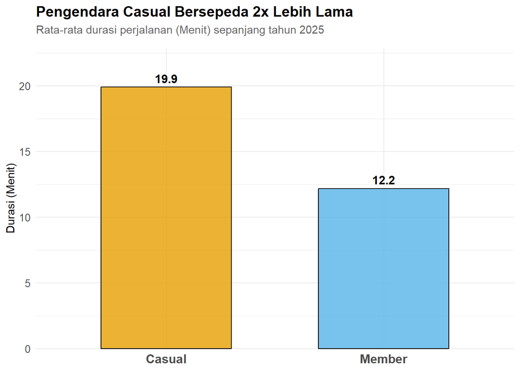

   ```r
   # 1. Menghitung Rata-rata Durasi per Tipe User
   duration_summary <- trips_viz %>%
     group_by(member_casual) %>%
     summarise(average_duration = mean(ride_length_minutes), .groups = 'drop')

   # 2. Membuat Grafik Batang (Bar Chart)
   ggplot(duration_summary, aes(x = member_casual, y = average_duration, fill = member_casual)) +
     geom_col(width = 0.6, color = "black", alpha = 0.8) +

     # Menambahkan teks angka di atas batang
     geom_text(aes(label = round(average_duration, 1)), vjust = -0.5, size = 4, fontface = "bold") +

     # Mengatur label sumbu X agar berhuruf kapital
     scale_x_discrete(labels = c("casual" = "Casual", "member" = "Member")) +

     # Memberi ruang napas di bagian atas grafik agar teks tidak terpotong
     scale_y_continuous(expand = expansion(mult = c(0, 0.15))) +

2. **Insight 2: Preferensi Waktu (Pola Mingguan)**

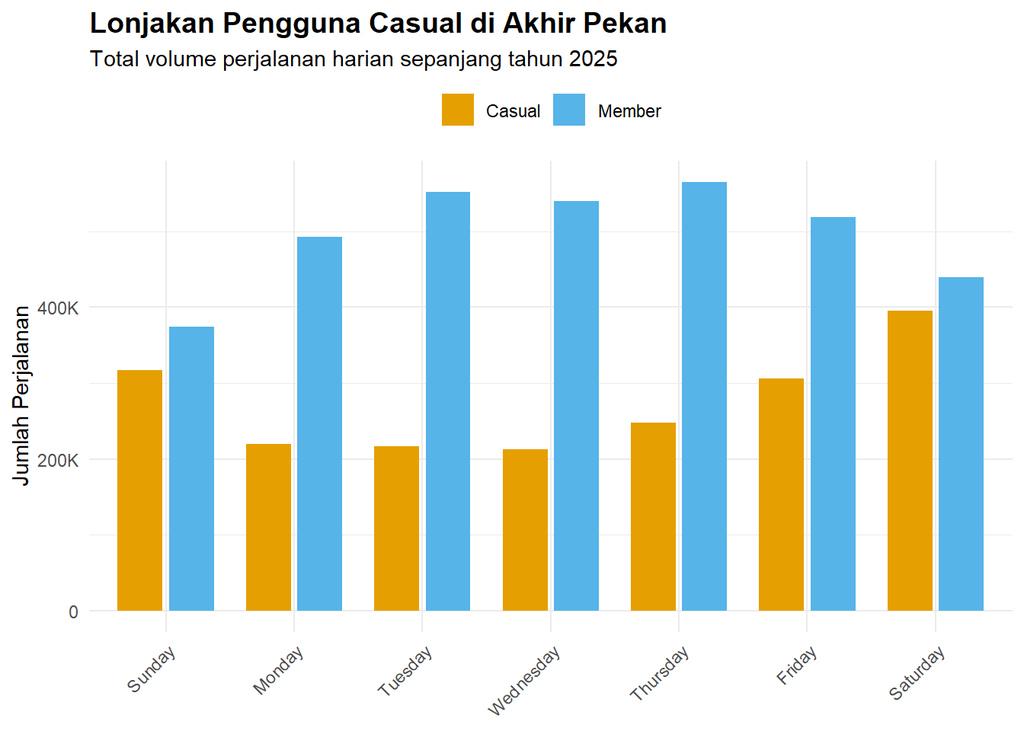

   ```r
   # Membuat Grafik Batang Ganda (Grouped Bar Chart)
   trips_viz %>%
     group_by(member_casual, day_name) %>%
     summarise(number_of_rides = n(), .groups = 'drop') %>%

     ggplot(aes(x = day_name, y = number_of_rides, fill = member_casual)) +
     geom_col(position = position_dodge(width = 0.8), width = 0.7) +

     # Format Axis Y menjadi "K" (Ribuan)
     scale_y_continuous(labels = label_number(scale_cut = cut_short_scale())) +

     # Styling
     labs(
       title = "Lonjakan Pengguna Casual di Akhir Pekan",
       subtitle = "Total volume perjalanan harian sepanjang tahun 2025",
       x = NULL,
       y = "Jumlah Perjalanan"
     ) +
     scale_fill_manual(values = c("casual" = "#E69F00", "member" = "#56B4E9"),
                       labels = c("Casual", "Member")) +
     theme_minimal() +
     theme(
       legend.position = "top",
       legend.title = element_blank(),
       plot.title = element_text(face = "bold", size = 14),
       axis.text.x = element_text(angle = 45, hjust = 1) # Miringkan teks hari
     )
   ```

3. **Insight 3: Komposisi Pengguna (Market Share)**

   ```r
   # 1. Menghitung Total & Persentase
   user_composition <- trips_viz %>%
     count(member_casual) %>%
     mutate(
       percentage = n / sum(n),
       label_text = scales::percent(percentage, accuracy = 1)
     )

   # Menampilkan angka di konsol (agar tercatat di laporan)
   print(user_composition)
   ```

   ```
   ## # A tibble: 2 × 4
   ##   member_casual       n percentage label_text
   ##   <fct>           <int>      <dbl> <chr>
   ## 1 casual        1915605      0.355 35%
   ## 2 member        3483958      0.645 65%
   ```

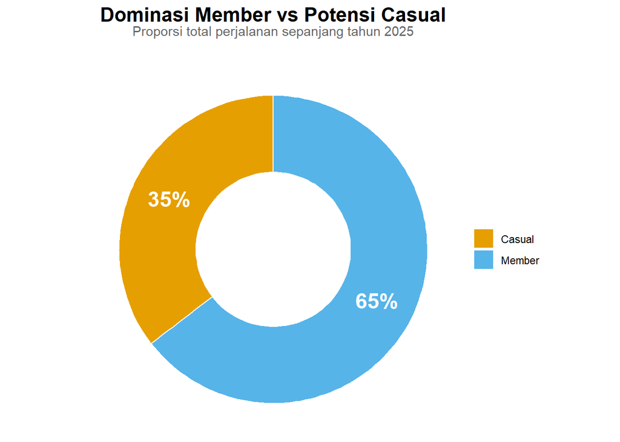

   ```r
   # 2. Visualisasi Pie Chart (Donut Chart)
   ggplot(user_composition, aes(x = 2, y = percentage, fill = member_casual)) +
     geom_bar(stat = "identity", color = "white", width = 1) +
     coord_polar(theta = "y", start = 0) +

     # Membuat lubang tengah (Donut Style)
     xlim(0.5, 2.5) +

     # Menambahkan Label Persentase di tengah area warna
     geom_text(aes(label = label_text), position = position_stack(vjust = 0.5), color = "white", fontface = "bold", size = 6) +

     # Styling & Konteks Narasi
     labs(
       title = "Dominasi Member vs Potensi Casual",
       subtitle = "Proporsi total perjalanan sepanjang tahun 2025"
     ) +
     scale_fill_manual(
       values = c("casual" = "#E69F00", "member" = "#56B4E9"),
       labels = c("Casual", "Member") # Kapitalisasi label legenda
     ) +
     theme_void() + # Menghilangkan background kotak (bersih)
     theme(
       legend.position = "right",
       legend.title = element_blank(), # Menghilangkan judul legenda yang kaku
       plot.title = element_text(face = "bold", size = 16, hjust = 0.5), # Judul rata tengah
       plot.subtitle = element_text(color = "grey40", hjust = 0.5, margin = margin(b = 15)) # Subtitle rata tengah dengan jarak
     )
   ```

4. **Visualisasi Interaktif & Geospasial (Tableau Dashboard)**

   Untuk analisis yang lebih mendalam mengenai **Lokasi (Geospatial)** dan **Waktu Sibuk (Heatmap)**, saya telah membuat Dashboard Interaktif menggunakan Tableau.

   Dashboard ini menjawab pertanyaan: *“Di mana lokasi favorit pengendara Casual dan kapan tepatnya kita harus menargetkan iklan?”*

[figure not shown]

[**👉 Akses Dashboard Tableau Interaktif di Sini**](https://public.tableau.com/views/All_trip_sepeda/Dashboard1?:language=en-US&publish=yes&:sid=&:redirect=auth&:display_count=n&:origin=viz_share_link)

### 5. Rekomendasi Bisnis (Act)

#### 2. Produk Baru: “Summer Weekend Pass”

- **Bukti (Heatmap & Seasonality):** Data menunjukkan pengguna Casual memuncak drastis pada **Sabtu-Minggu** pukul 10:00-16:00, terutama selama bulan **Juni-Agustus**.
- **Tindakan:** Luncurkan keanggotaan musiman khusus (misal: *Summer Pass* atau *Weekend-Only Membership*). Ini memberikan opsi yang lebih murah daripada Full Membership bagi pengguna yang hanya aktif saat liburan, namun tetap mengikat mereka dalam ekosistem Cyclistic.